# 2x2 Linear Mixed Effect Models

Matt Jaquiery

10/09/2019

## Introduction

This guide covers data simulation and power analysis using linear mixed effects modelling. For a basic introduction to the topic, see Lisa DeBruine and Dale Barr’s [helpful tutorial](https://debruine.github.io/lmem_sim/index.html). This guide extends the process to cover two predictors, and will explain how to specify the random effects in order to the high false-positive rate that [occurs otherwise](https://www.frontiersin.org/articles/10.3389/fpsyg.2013.00328/full). We will not be dealing with covariation in the effects.

## Data

First we want some data to play with. We’ll imagine the following, closely based on my own research:

> Participants complete a quiz where they encounter questions asking them to estimate things (and tell us how sure they are). They then get advice on those estimates and provide a final estimate.

We have the following variables:

| variable | name | values |
| --- | --- | --- |
| Participant ID | `pID` | [nominal] |
| Question ID | `qID` | [nominal] |
| Confidence | `conf` | low \| high |
| Advisor type | `advisor` | bias-sharing \| anti-bias |

We use the amount participants moved their estimate from before they got advice as our measure of advice taking ($\text{woa} = \text{weight on advice} = (\text{final estimate - initial estimate}) / (\text{advice estimate - initial estimate})$). This is our outcome variable, and we’re interested in how it is predicted by the interaction of advisor type and confidence.

We’ll generate that data with some pre-specified effects according to the same formula we’ll use to analyse it (and hopefully recover our parameters!). That formula will be:

### Generative model

$$\text{woa} = b0 +
b1_\text{pID} +
b2_\text{qID} +
b3 \cdot \text{conf} + b4_\text{pID} \cdot \text{conf} + b5_\text{qID} \cdot \text{conf} +
b6 \cdot \text{advisor} + b7_\text{pID} \cdot \text{advisor} + b8_\text{qID} \cdot \text{conf} +
b9 \cdot \text{advisor} \cdot \text{conf} + b10_\text{pID} \cdot \text{conf} \cdot \text{advisor} + b11_\text{qID} \cdot \text{conf} \cdot \text{advisor}$$
where the random effects are drawn from normal distrbutions with standard deviations specified by the beta.
$$bX_i ~ \sim \mathcal{N}(0, bX)$$

Yes, that’s a lot of parameters. But they split into a mixture of random effects and fixed effects. Random effects provide individual observations over which we’ll generalise, while fixed effects give specific values we’ll want to estimate. Any variable which involves the `pID` or `qID` will be a random effect.

#### Effects

Random effects are in plainface, **fixed effects** in **boldface**

- **$b0$ = grand mean for advice-taking**
- $b1_\text{pID}$ = participant’s propensity to take advice
- $b1_\text{qID}$ = amount of advice-taking due to the question asked (probably due to difficulty!)
- **$b3 \cdot \text{conf}$ = amount confidence affects advice-taking**
- $b4_\text{pID} \cdot \text{conf}$ = participant’s variation in effect of confidence on advice-taking
- $b5_\text{qID} \cdot \text{conf}$ = item variation in effect of confidence on advice-taking
- **$b6 \cdot \text{advisor}$ = amount advisor affects advice-taking**
- $b7_\text{pID} \cdot \text{advisor}$ = participant’s variation in effect of advisor on advice-taking
- $b8_\text{qID} \cdot \text{advisor}$ = item variation in effect of advisor on advice-taking
- **$b9 \cdot \text{advisor} \cdot \text{conf}$ = interaction of confidence and advisor on advice-taking**
- $b10_\text{pID} \cdot \text{conf} \cdot \text{advisor}$ = participant’s variation in interaction effect
- $b11_\text{qID} \cdot \text{conf} \cdot \text{advisor}$ = item variation in interaction effect

### Make it so

First we want to specify the design of the experiment. We have 100 questions, but each participant will only answer 30 of them. This kind of design is unusual, and means that some questions will have more instances over which we can generalise to others (meaning the random effects of those questions are estimated more precisely), but that’s okay. We’re not as sensitive to missing data using linear mixed models as we would be using ANOVA. We’ll also have 50 participants and each question/participant combination (i.e. each observation) will have one of two confidences (high or low) and advice from one of two advisors (bias-sharing or anti-bias). The data will be in long format.

```r
library(tibble)
n <- list(
  p = 50,   # number of participants
  q = 100,  # number of questions in the question set
  obs = 30  # number of questions answered by each participant
  )

d <- tibble(
  pID = rep(factor(1:n$p), each = n$obs),
  qID = NA,
  confRating = sample(factor(c("low", "high")), n$p * n$obs, replace = T),
  advisorName = factor(rep(c("bias-sharing", "anti-bias"), n$p * n$obs / 2))
)

# Assign question numbers
for (p in unique(d$pID)) {
  d$qID[d$pID == p] <- sample(1:n$q, n$obs)
}

# adapt the conf and advisor ratings to the values we'll want to use in the models
d$conf <- as.numeric(d$confRating) - 1
d$advisor <- as.numeric(d$advisorName) - 1
```

**Note:** Many implementations of LME code two-level categorical variables with -.5 and +.5 so that the other estimates give the mean across both categories rather than the mean for the first category. We use 0 and 1 as is familiar from basic linear modelling because we are interested in the interactions (and .5.5 = -.5*-.5 meaning ‘interactions’ would group cases where the levels were the same rather than where both levels were the higher category).

Next we specify some sizes for all the betas in our model. Each beta represents the change in weight-on-advice, which is a proportion between 0 and 1 (0 = sticking with one’s initial estimate; 1 = fully adopting the advised estimate).

```r
b <- list(
  b0 = .0,  # grand mean
  b1 = .2,  # SD of participant variation in mean
  b2 = .2,  # SD of item variation in mean
  b3 = .3,  # effect of CONF
  b4 = .1,  # SD of participant variation in b3
  b5 = .1,  # SD of item variation in b3
  b6 = .1,  # effect of ADVISOR
  b7 = .1,  # SD of participant variation in b6
  b8 = .1,  # SD of item variation in b6
  b9 = .3,  # effect of CONF * ADVISOR
  b10 = .1, # SD of participant variation in b9
  b11 = .1, # SD of item variation in b9
  noise = .1
)

# function to fetch consistent values for each x from a normal distribution with
# sd = sd
f <- function(sd, x) {
  if (length(x) > 1) {
    return(sapply(x, function(x) f(sd, x)))
  }
  set.seed(as.numeric(x))
  rnorm(1, sd = as.numeric(sd))
}
```

Finally we can use the model to calculate the weight-on-advice for each observation.

```r
d$woaRaw <-
  b$b0 +                                  # grand mean
  f(b$b1, d$pID) +                        # SD of participant variation in mean
  f(b$b2, d$qID) +                        # SD of item variation in mean

  b$b3 * d$conf +                         # effect of CONF
  f(b$b4, d$pID) * d$conf +               # SD of participant variation in b3
  f(b$b5, d$qID) * d$conf +               # SD of item variation in b3

  b$b6 * d$advisor +                      # effect of ADVISOR
  f(b$b7, d$pID) * d$advisor +            # SD of participant variation in b6
  f(b$b8, d$qID) * d$advisor +            # SD of item variation in b6

  b$b9 * d$conf * d$advisor +             # effect of CONF * ADVISOR
  f(b$b10, d$pID) * d$conf * d$advisor +  # SD of participant variation in b9
  f(b$b11, d$qID) * d$conf * d$advisor +  # SD of item variation in b9

  rnorm(nrow(d), sd = b$noise)    # random noise

# Cap woa to between 0 and 1
d$woa <- pmin(1, pmax(0, d$woaRaw))

d
```

```
## # A tibble: 1,500 x 8
##    pID     qID confRating advisorName   conf advisor woaRaw   woa
##    <fct> <int> <fct>      <fct>        <dbl>   <dbl>  <dbl> <dbl>
##  1 1        94 low        bias-sharing     1       1  0.877 0.877
##  2 1        17 high       anti-bias        0       0 -0.216 0
##  3 1        75 high       bias-sharing     0       1 -0.523 0
##  4 1        95 high       anti-bias        0       0 -0.278 0
##  5 1        42 high       bias-sharing     0       1  0.413 0.413
##  6 1        67 high       anti-bias        0       0  0.275 0.275
##  7 1        45 low        bias-sharing     1       1  0.393 0.393
##  8 1        37 high       anti-bias        0       0 -0.185 0
##  9 1        24 high       bias-sharing     0       1 -0.406 0
## 10 1        64 high       anti-bias        0       0 -0.482 0
## # ... with 1,490 more rows
```

### Plot the data

We’ll plot a subset of the data; 9 participants.

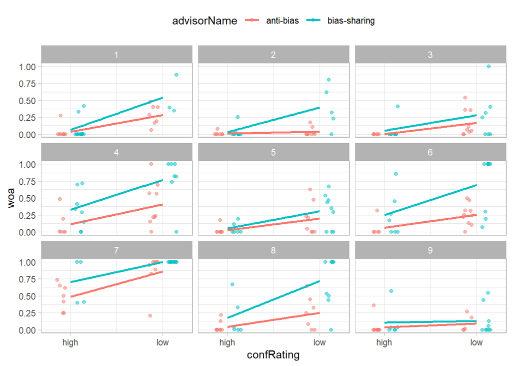

```r
library(ggplot2)
ggplot(d[as.numeric(d$pID) < 10, ],
       aes(x = conf, y = woa, colour = factor(advisor))) +
  geom_point(alpha = .5, position = position_jitterdodge(dodge.width = .4,
                                                         jitter.width = .2)) +
  geom_smooth(method = "lm", se = F) +
  facet_wrap(~pID) +
  scale_x_continuous(breaks = c(0, 1), labels = levels(d$confRating), name = "confRating") +
  scale_color_discrete(labels = levels(d$advisorName), name = "advisorName") +
  theme_light() +
  theme(legend.position = "top")
```

## Parameter recover

The next step is to try to pull the parameters we supplied to the model out from the data we generated. We do this by using linear mixed effect modelling for analysis.

### Specifying the model

```r
library(lmerTest)
model <- woa ~
  1 +                         # b0 grand mean

  (1 | pID) +                 # b1 participant intercept
  (1 | qID) +                 # b2 item intercept

  conf +                      # b3 confidence slope

  (0 + conf | pID) +          # b4 participant conf slope
  (0 + conf | qID) +          # b5 item conf slope

  advisor +                   # b6 advisor slope

  (0 + advisor | pID) +       # b7 participant advisor slope
  (0 + advisor | qID) +       # b8 item advisor slope

  conf:advisor +              # b9 interaction slope

  (0 + conf:advisor | pID) +  # b10 participant interaction slope
  (0 + conf:advisor | qID) +  # b11 item interaction slope

                              # Noise is assumed
  NULL
```

### Running the analysis

```r
out <- summary(lmer(model, data = d, REML = F))

out
```

```
## Linear mixed model fit by maximum likelihood . t-tests use
##   Satterthwaite's method [lmerModLmerTest]
## Formula: model
##    Data: d
##
##      AIC      BIC   logLik deviance df.resid
##  -1296.8  -1227.7    661.4  -1322.8     1487
##
## Scaled residuals:
##      Min       1Q   Median       3Q      Max
## -3.09340 -0.54224 -0.01088  0.55482  3.00417
##
## Random effects:
##  Groups   Name         Variance Std.Dev.
##  qID      conf:advisor 0.004283 0.06545
##  qID.1    advisor      0.005786 0.07607
##  qID.2    conf         0.015455 0.12432
##  qID.3    (Intercept)  0.015877 0.12600
##  pID      conf:advisor 0.007709 0.08780
##  pID.1    advisor      0.002135 0.04620
##  pID.2    conf         0.009170 0.09576
##  pID.3    (Intercept)  0.014981 0.12240
##  Residual              0.013147 0.11466
## Number of obs: 1500, groups:  qID, 100; pID, 50
##
## Fixed effects:
##               Estimate Std. Error        df t value Pr(>|t|)
## (Intercept)    0.10600    0.02234  94.14566   4.746 7.40e-06 ***
## conf           0.20320    0.02060 102.33757   9.866  < 2e-16 ***
## advisor        0.08654    0.01361  92.66844   6.358 7.61e-09 ***
## conf:advisor   0.15291    0.01933  76.64377   7.909 1.57e-11 ***
## ---
## Signif. codes:  0 '***' 0.001 '**' 0.01 '*' 0.05 '.' 0.1 ' ' 1
##
## Correlation of Fixed Effects:
##             (Intr) conf   advisr
## conf        -0.089
## advisor     -0.133  0.145
## conf:advisr  0.095 -0.217 -0.324
```

### Comparing the input values and output estimates

```r
rx <- out$varcor
fx <- out$coefficients

# Nice summary dataframe of the input effect vs the recovered effect
fxt <- cbind(fx, data.frame(input = c(b$b0, b$b3, b$b6, b$b9)))
rxt <- cbind(as.data.frame(rx),
             data.frame(input = c(
               # order is irritating
               b$b11, b$b8, b$b5, b$b2, # item stuff
               b$b10, b$b7, b$b4, b$b1, # participant stuff
               b$noise)))
rxt <- rxt[, c(1:2, 5:6)]

fxt
```

```
##                Estimate Std. Error        df  t value     Pr(>|t|) input
## (Intercept)  0.10599757 0.02233540  94.14566 4.745720 7.396728e-06   0.0
## conf         0.20320391 0.02059663 102.33757 9.865883 1.563494e-16   0.3
## advisor      0.08654469 0.01361221  92.66844 6.357872 7.613632e-09   0.1
## conf:advisor 0.15290596 0.01933432  76.64377 7.908526 1.567617e-11   0.3
```

```r
rxt
```

```
##        grp         var1      sdcor input
## 1      qID conf:advisor 0.06544634   0.1
## 2    qID.1      advisor 0.07606856   0.1
## 3    qID.2         conf 0.12431658   0.1
## 4    qID.3  (Intercept) 0.12600352   0.2
## 5      pID conf:advisor 0.08779813   0.1
## 6    pID.1      advisor 0.04620172   0.1
## 7    pID.2         conf 0.09576227   0.1
## 8    pID.3  (Intercept) 0.12239547   0.2
## 9 Residual         <NA> 0.11466032   0.1
```